# S7 Cruelty free

Por lo tanto, hasta el momento hay suficiente evidencia que explique que halla una relación entre las variables CantidadCambio y Pubmaltrato.

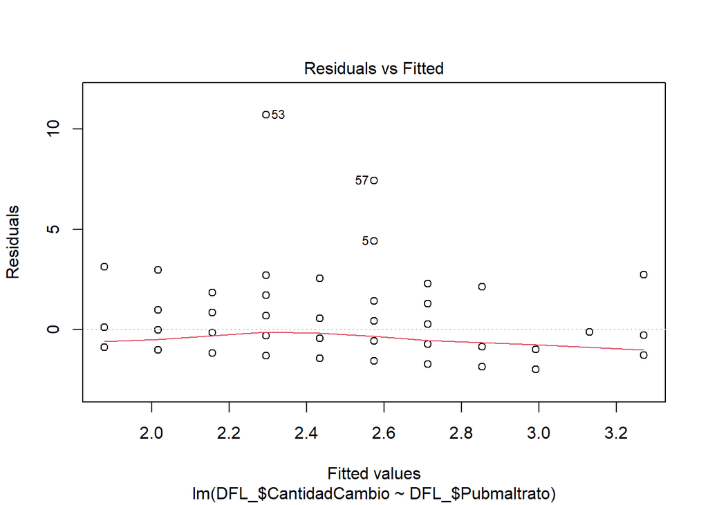

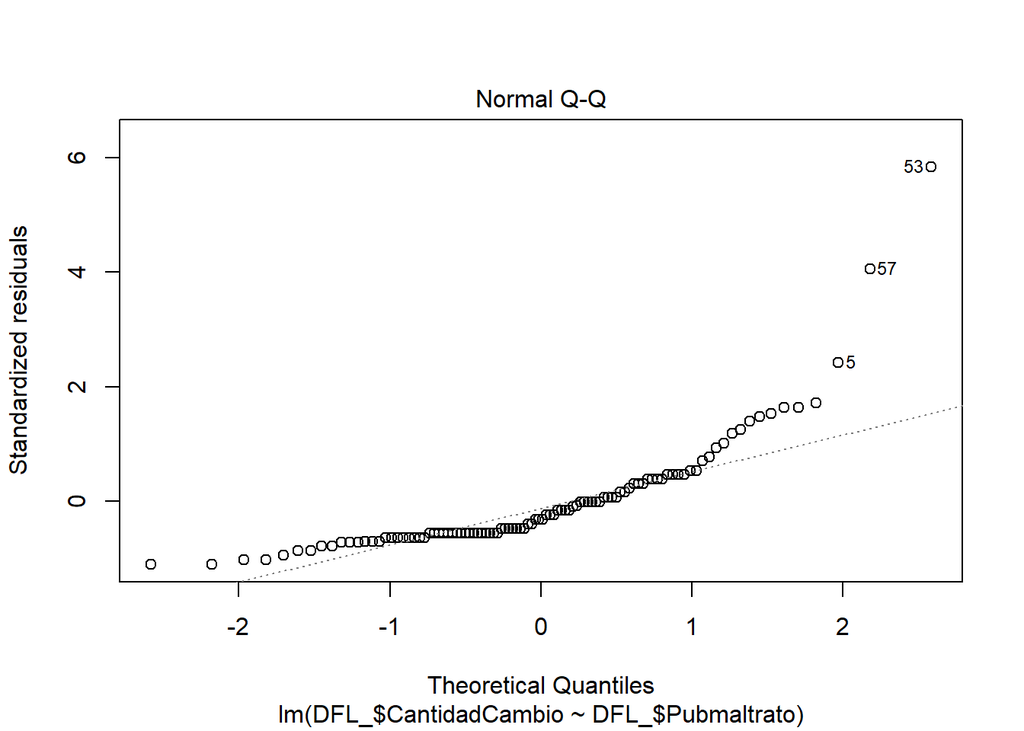

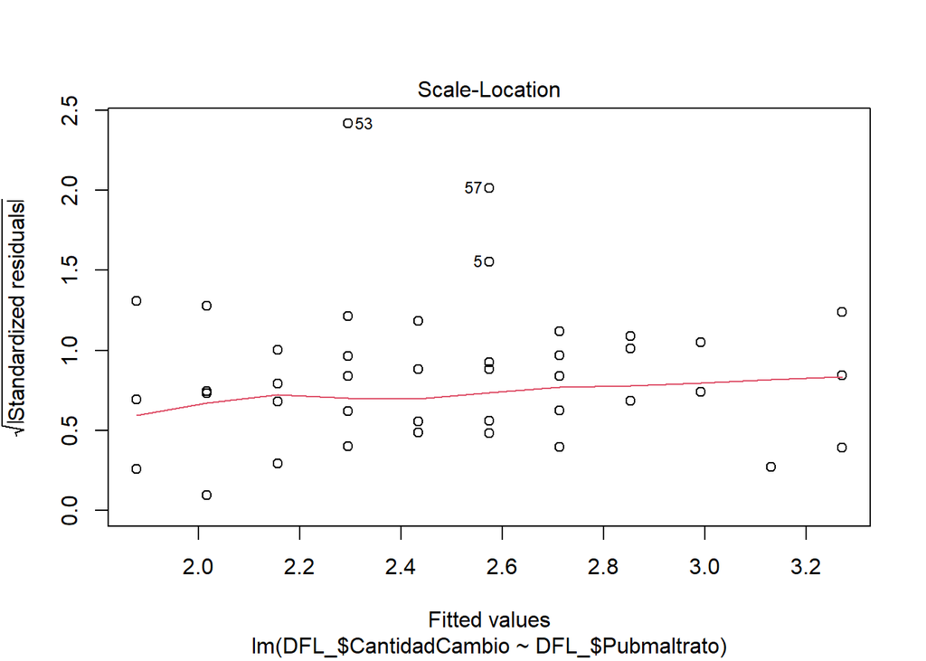

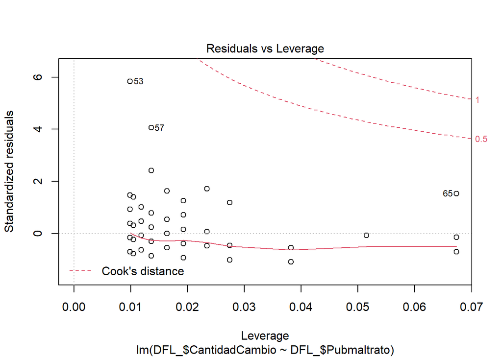

- Residuals vs Fitted: La recta roja es relativamente cercana a la recta 0, en ambos extremos de la recta es donde se aleja de la recta y=0.
- Normal Q-Q: Para esta gráfica, se observa que el conjunto de puntos no es tan cercano a la recta y=x. Se acentúa sobremanera en el extremo superior.
- Scale - Location: Observamos que la línea roja no es estrictamente plana. Sugiere que los datos no son homocedásticos.
- Residuals vs Leverage: La recta es casi paralela a la recta y=0.

Tras lo analizado, podemos formular una ecuación que relacione ambas variables. Los coeficientes son:

```
##      (Intercept) DFL_$Pubmaltrato
##        1.8766396        0.1394694
```

Predicción: ¿Qué cantidad de productos que no son cruelty free dejó de comprar una persona que haya visto 8 publicidades sobre el maltrato animal en el último mes?

```
## [1] 2.99
```

Concluimos que la persona dejó de comprar aproximadamente 3 productos.

3. Conocimientosincf vs ProductoMes

Variables a estudiar: Conocimientosincf y ProductoMes. La significancia fijada es de 0.05.

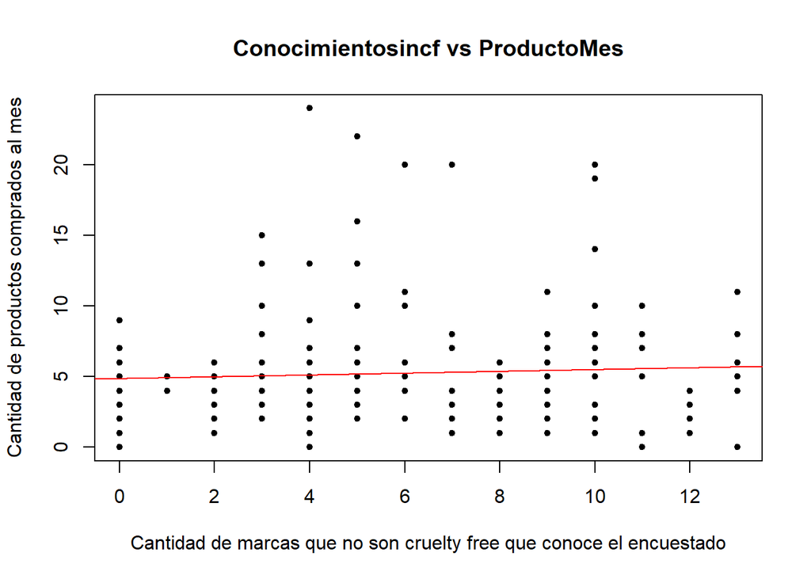

```
## [1] 0.05730961
```

La correlación es cercana a 0. Esto podría deberse a que los datos están medianamente distribuidos como se puede notar en la parte inferior de la gráfica.

```
##
## Call:
## lm(formula = DFL$ProductoMes ~ DFL$Conocimientosincf)
##
## Residuals:
##     Min      1Q  Median      3Q     Max
## -5.7190 -2.3953 -0.9420  0.9285 18.8637
##
## Coefficients:
##                       Estimate Std. Error t value Pr(>|t|)
## (Intercept)            4.87726    0.60008   8.128  6.1e-14 ***
## DFL$Conocimientosincf  0.06475    0.08293   0.781    0.436
## ---
## Signif. codes:  0 '***' 0.001 '**' 0.01 '*' 0.05 '.' 0.1 ' ' 1
##
## Residual standard error: 4.091 on 185 degrees of freedom
## Multiple R-squared:  0.003284,   Adjusted R-squared:  -0.002103
## F-statistic: 0.6096 on 1 and 185 DF,  p-value: 0.4359
```

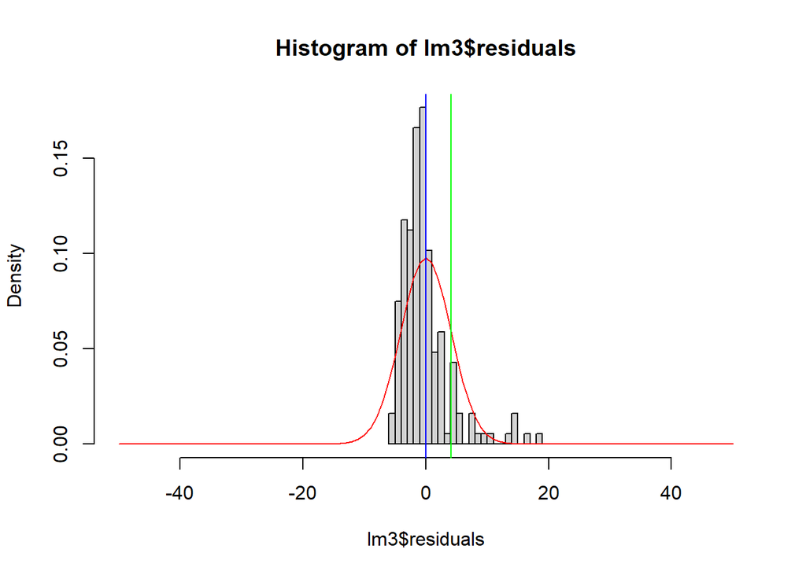

Observamos que la distribución de la gráfica no es simétrica, por lo que no se acerca a una distribución normal; además de que presenta un valor atípico. Sin embargo, notamos que la media de los valores de los residuales es muy cercano a 0.

Por lo tanto, hasta el momento no hay suficiente evidencia que explique que halla una relación entre las variables ProductoMes y Conocimientosincf.

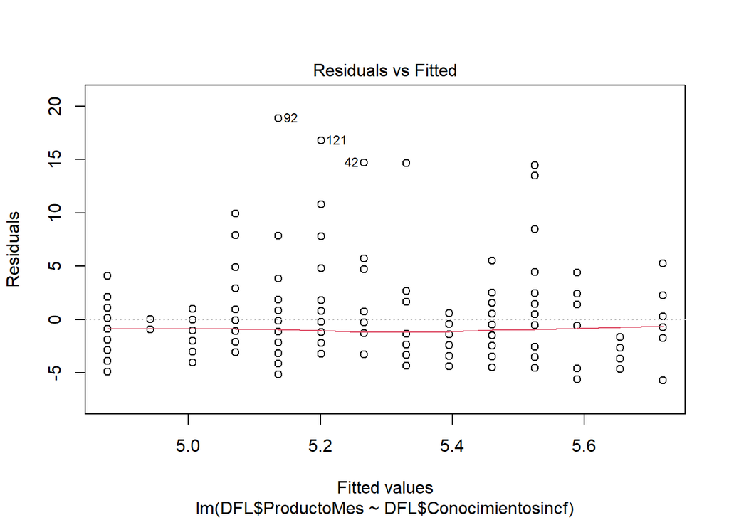

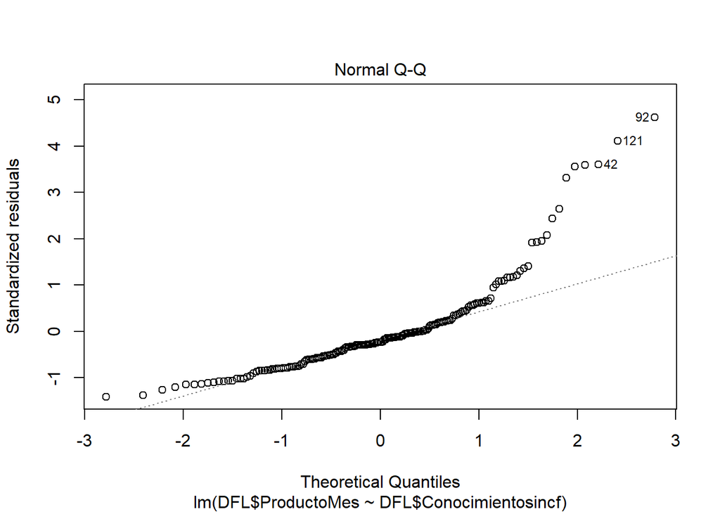

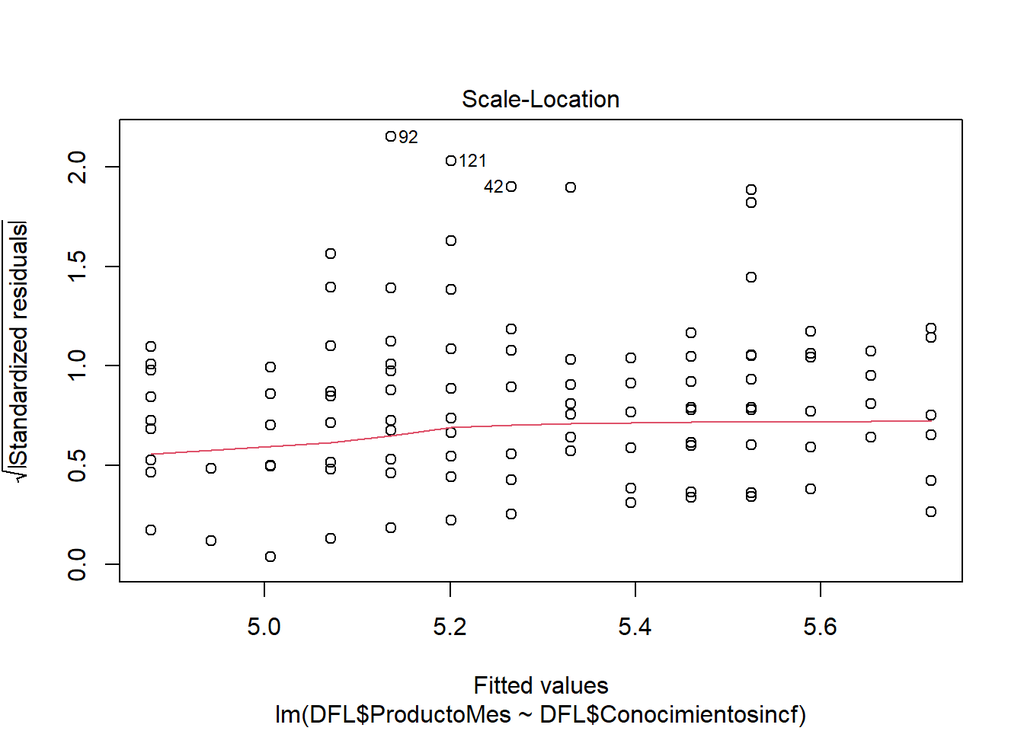

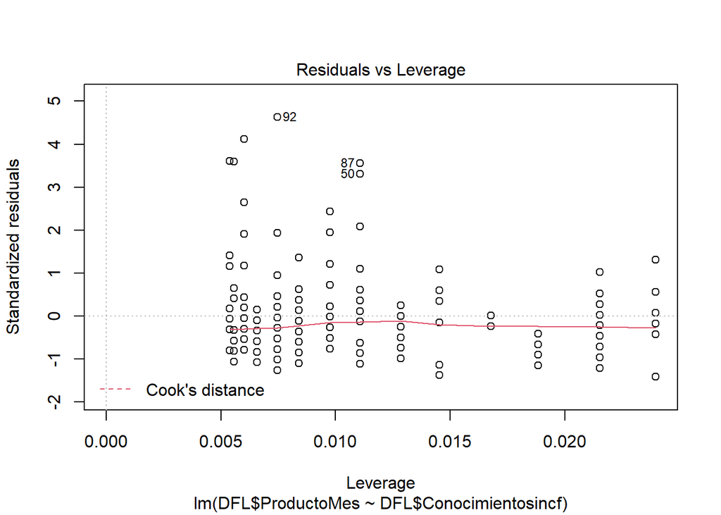

- Residuals vs Fitted: La recta roja es relativamente paralela a la recta 0.

- Normal Q-Q: Para esta gráfica, se observa que el conjunto de puntos no es tan cercano a la recta y=x. Se acentúa sobremanera en el extremo superior.
- Scale - Location: Observamos que la línea roja no es estrictamente plana. Sugiere que los datos no son homocedásticos.
- Residuals vs Leverage: La recta se acerca al 0, aunque no demasiado.

En base al análisis realizado, no podemos establecer una ecuación que relacione ambas variables.

### Bibliografía

- APEIM. (2020, octubre). Niveles Socioeconómicos 2020. http://apeim.com.pe/wp-content/uploads/2020/10/APEIM-NSE-2020.pdf
- Busca empresas latinas libres de crueldad. (2021, 13 mayo). PETA Latino. https://www.petalatino.com/campanas/busca-empresas-libres-de-crueldad/
- Características de los niveles socioeconómicos en el Perú. (2020, 13 febrero). Ipsos. https://www.ipsos.com/es-pe/caracteristicas-de-los-niveles-socioeconomicos-en-el-peru
- El Planeta Urbano. (2018, October). NATURA CRUELTY FREE. El Planeta Urbano. https://elplanetaurbano.com/2018/10/natura-cruelty-free/
- Heffner, E. (2021, 13 abril). Taika Waititi, Ricky Gervais, Zac Efron, Olivia Munn and more star in ’s animated short film Save Ralph in aid of global campaign to ban cosmetic testing on animals. Humane Society International. https://www.hsi.org/news-media/taika-waititi-ricky-gervais-zac-efron-olivia-munn-and-more-star-in-hsi-short-film-save-ralph-in-aid-of-global-campaign-to-ban-animal-cosmetic-testing-global/
- INEI. (2013, julio). Población y territorio. https://www.inei.gob.pe/media/MenuRecursivo/publicaciones_digitales/Est/Lib1095/libro.pdf
- Listado de marcas libres de testeo en Perú. (2019, 15 abril). ONG Te Protejo. https://ongteprotejo.org/pe/datos/listado-de-marcas-libres-de-testeo-en-peru/
- Ralph. (2021, 9 mayo). Humane Society International. https://www.hsi.org/saveralphmovie/
- No testado en animales. (2018, December 3). No testado en animales. Dove UK. https://www.dove.com/pe/stories/about-dove/no-animal-testing.html#:~:text=Dove%20no%20testea%20en%20animales,de%20nuestros%20productos%20e%20ingredientes.